# Sinusoidal reef size spectra

F. J. Heather

23/02/2021

This code will recreate all the figures for the study titled “Reef communities show highly linear abundance size spectra, with small predictable inflections”

# Model fitting

## Nonlinear

Nonlinear size spectrum model, fitted to each site:

$$log(N) \sim \beta_{0,s} + \lambda_s \cdot log(M) + A_s \cdot sin(\frac{2 \cdot \pi \cdot log(M)}{D_s}-P_s)$$
where N is the normalised abudnance, M is the middle of the size bin, $\beta_0$ is the interecept, $\lambda$ is the slope, A is the wave amplitude, D is the wavelength, P is the wave phase and s is the site ID.

```r
# fitting the nonlinear model
# reasonable start values to avoid wild fits
fit_sine_nls <- function(df, start_A = 5, start_D = 17, start_P = 3.2) {


  lm_mod <- lm(log(norm_density, base= sqrt(2))   ~ log(bin_mid, base= sqrt(2)), data=df)
  start_beta_0 = lm_mod %>% coefficients() %>% .[1] %>% as.numeric()
  start_lambda = lm_mod %>% coefficients() %>% .[2] %>% as.numeric()


  nls(logsqrt2_norm_density ~
        beta_0 +
        lambda*(logsqrt2_bin_mid) +
        A*sin(((2*pi*logsqrt2_bin_mid)/D)-P),
      data=data.frame(df),
      start=list(A      = start_A,
                 D      = start_D,
                 P      = start_P,
                 beta_0 = start_beta_0,
                 lambda = start_lambda),
      upper=c(10,
              30,
              10,
              50,
              0),
      lower=c(0,0, 0, 0, -4),
      algorithm = "port")
}

# extracting coefs from the nonlinear model
get_sine_coefs <- function(sin_mod){
  sin_mod %>%
    coef() %>%
    as.data.frame(colnames="value") %>%
    rownames_to_column("coef") %>%
    rename("value" = ".") %>%
    as_tibble()
}

# used to find local peaks in abundance
sine_func <- function(x, A, P , D) {
  A*sin(((2*pi*x)/D)-P)
}

nls_output <-
  main_df %>%
  select(site_code, bin_mid, norm_density) %>%
  mutate(logsqrt2_norm_density = logsqrt2(norm_density)) %>%
  mutate(logsqrt2_bin_mid = logsqrt2(bin_mid)) %>%
  na.omit() %>%
  group_by(site_code) %>%
  nest() %>%
  mutate(nls_mod = map(.x = data, ~possibly(fit_sine_nls, otherwise = NA_real_)(.x))) %>%
  mutate(nls_coefs = map(.x = nls_mod, ~possibly(get_sine_coefs, otherwise = NA_real_)(.x))) %>%
  mutate(nls_fit = map(.x = nls_mod, ~possibly(predict, otherwise = NA_real_)(.x))) %>%
  mutate(nls_AIC = map_dbl(.x = nls_mod, .f = ~possibly(AIC, otherwise = NA_real_)(.x)))

nls_coefs <-
  nls_output %>%
  select(site_code, nls_coefs) %>%
  unnest(cols = c(nls_coefs)) %>%
  pivot_wider(names_from = coef, values_from = value) %>%
  select_if(~sum(!is.na(.)) > 0) %>%
  mutate(peak = optimize(sine_func,
                         interval=c(10, 20),
                         maximum=TRUE,
                         A = A,
                         D = D,
                         P = P)[1] %>%
           as.numeric()) %>%
  ungroup()

mod_fits <-
  nls_output %>%
  select(site_code, data,  nls_fit) %>%
  unnest(cols = c(data,  nls_fit)) %>%
  select(-c(logsqrt2_norm_density, logsqrt2_bin_mid)) %>%
  mutate(nls_fit = sqrt(2)^nls_fit)
```

## Linear (per site)

A linear model fitted to each site (for comparison purposes with the nonlinear model)

$$log(N) \sim \beta_{0, s} + \lambda_s \cdot log(M) + s$$

```r
fit_lm <- function(df){
  lm(logsqrt2_norm_density ~ logsqrt2_bin_mid,
     data=data.frame(df))

}

lm_output <-
  main_df %>%
  select(site_code, bin_mid, norm_density) %>%
  mutate(logsqrt2_norm_density = logsqrt2(norm_density)) %>%
  mutate(logsqrt2_bin_mid = logsqrt2(bin_mid)) %>%
  na.omit() %>%
  group_by(site_code) %>%
  nest() %>%
  mutate(lm_mod = map(.x = data, ~possibly(fit_lm, otherwise = NA_real_)(.x))) %>%
  mutate(lm_AIC = map_dbl(.x = lm_mod, .f = ~possibly(AIC, otherwise = NA_real_)(.x))) %>%
  mutate(lm_fit = map(.x = lm_mod, ~possibly(predict, otherwise = NA_real_)(.x))) %>%
  mutate(tidy_lm = map(lm_mod, ~tidy(.x)))

lm_coefs <-
  lm_output %>%
  select(site_code, tidy_lm) %>%
  unnest(cols = tidy_lm)

lm_fits <-
  lm_output %>%
  select(site_code, data,  lm_fit) %>%
  unnest(cols = c(data,  lm_fit)) %>%
  select(-c(logsqrt2_norm_density, logsqrt2_bin_mid)) %>%
  mutate(lm_fit = sqrt(2)^lm_fit)
```

## Linear (drop-off removed)

```r
fit_lm <- function(df){
  lm(logsqrt2_norm_density ~ logsqrt2_bin_mid,
     data=data.frame(df))
}

max_dens <-
  main_df %>%
  filter(type %in% c("macro", "both")) %>%
  group_by(site_code) %>%
  nest() %>%
  mutate(max_dens = map_dbl(data, ~max(.x$norm_density, na.rm = T))) %>%
  unnest(cols = data) %>%
  filter(max_dens == norm_density) %>%
  select(site_code, bin_mid_max = bin_mid)

lm_output2 <-
  main_df %>%
  left_join(max_dens) %>%
  filter(!(type == "macro" & bin_mid < bin_mid_max)) %>%
  filter(type != "both") %>%
  select(site_code, bin_mid, norm_density) %>%
  mutate(logsqrt2_norm_density = logsqrt2(norm_density)) %>%
  mutate(logsqrt2_bin_mid = logsqrt2(bin_mid)) %>%
  na.omit() %>%
  group_by(site_code) %>%
  nest() %>%
  mutate(lm2_mod = map(.x = data, ~possibly(fit_lm, otherwise = NA_real_)(.x))) %>%
  mutate(lm2_AIC = map_dbl(.x = lm2_mod, .f = ~possibly(AIC, otherwise = NA_real_)(.x))) %>%
  mutate(tidy_lm = map(lm2_mod, ~tidy(.x)))
lm_coefs2 <-
  lm_output2 %>%
  select(site_code, tidy_lm) %>%
  unnest(cols = tidy_lm)
```

## Linear (all sites)

A linear model for all sites combined, to see how much variation in abundance is explained by body size alone.

$$log(N) \sim \beta_{0} + \lambda \cdot log(M)$$

## Comparing model fits

```r
decplaces <- function(x) format(round(x, 1), nsmall = 1)

lm_comparison_data <-
  lm_output %>%
  select(site_code, lm_AIC) %>%
  left_join(nls_output %>%
              select(site_code, nls_AIC)) %>%
  left_join(lm_output2 %>%
              select(site_code, lm2_AIC)) %>%
  mutate(hypothesis = case_when(lm2_AIC < lm_AIC & lm2_AIC < nls_AIC ~ "H1",
                                nls_AIC <= lm_AIC & nls_AIC <= lm2_AIC ~ "H2",
                                lm_AIC <= lm2_AIC & lm_AIC <= nls_AIC ~ "NA")) %>%
  mutate(lm_AIC_delta = lm_AIC-lm_AIC) %>%
  mutate(nls_AIC_delta = nls_AIC-lm_AIC) %>%
  mutate(lm2_AIC_delta = lm2_AIC-lm_AIC) %>%
  mutate(lm_AIC_delta = lm_AIC_delta %>% decplaces) %>%
  mutate(nls_AIC_delta = nls_AIC_delta %>% decplaces) %>%
  mutate(lm2_AIC_delta = lm2_AIC_delta %>% decplaces) %>%
  select(site_code, lm_AIC_delta, nls_AIC_delta, lm2_AIC_delta, hypothesis)
# H1: Sampling bias
lm_comparison_data %>%
  filter(hypothesis == "H1")
```

```
## # A tibble: 3 x 5
## # Groups:   site_code [3]
##   site_code lm_AIC_delta nls_AIC_delta lm2_AIC_delta hypothesis
##   <chr>     <chr>        <chr>         <chr>         <chr>
## 1 NIN-S1    0.0          -0.1          -8.6          H1
## 2 NIN-S2    0.0          0.3           -8.5          H1
## 3 NSW47     0.0          -9.0          -15.3         H1
```

```r
# H2: Nonlinear, continuous
lm_comparison_data %>%
  filter(hypothesis == "H2")
```

```
## # A tibble: 41 x 5
## # Groups:   site_code [41]
##    site_code lm_AIC_delta nls_AIC_delta lm2_AIC_delta hypothesis
##    <chr>     <chr>        <chr>         <chr>         <chr>
##  1 BS-S8     0.0          -23.9         0.0           H2
##  2 DE4       0.0          -11.3         0.0           H2
##  3 DE46      0.0          -4.6          0.0           H2
##  4 DE7       0.0          -20.2         0.0           H2
##  5 EMR1      0.0          -34.8         -5.1          H2
##  6 EMR18     0.0          -16.7         -5.5          H2
##  7 EMR2      0.0          -36.9         0.0           H2
##  8 EMR20     0.0          -13.8         0.0           H2
##  9 EMR25     0.0          -26.6         -5.2          H2
## 10 EMR37     0.0          -17.5         0.0           H2
## # ... with 31 more rows
```

```r
# H3: Combining data
lm_comparison_data %>%
  filter(hypothesis == "H3")
```

```
## # A tibble: 0 x 5
## # Groups:   site_code [0]
## # ... with 5 variables: site_code <chr>, lm_AIC_delta <chr>,
## #   nls_AIC_delta <chr>, lm2_AIC_delta <chr>, hypothesis <chr>
```

```r
# but the site does not contain any "both" type bins - i.e. is just linear in general
```

# Main text

## Figure 1

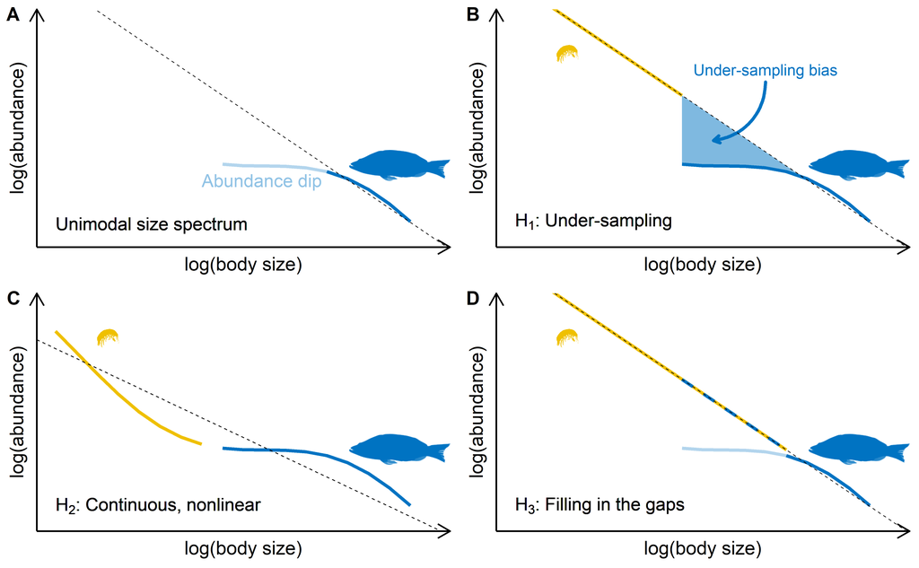

```r
mypal = ggsci::pal_jco(alpha = 1)(9)
meio_col <- mypal[2]
macr_col <- mypal[1]
both_col <- mypal[4]

dummy_data <-
  tibble(x = -10:10,
         y = -0.1 +
           -1.75*(x) +
           5*sin(((2*pi*x)/18)-0.7)) %>%
  mutate(type = case_when(x>=0 ~ "macro",
                          TRUE ~ "meio"))

dummy_lm <- lm(y~x, data = dummy_data %>% filter(x >=5))
dummy_lm_intcp <- dummy_lm$coefficients[1]
dummy_lm_slope <- dummy_lm$coefficients[2]

fish_image <-
  magick::image_read_svg("data/base/ian-symbol-serranus-scriba.svg", width = 250) %>%
  magick::image_colorize(opacity = 100, color= macr_col)

copepod_image <-
  magick::image_read_svg("data/base/ian-symbol-amphipod.svg", width = 350) %>%
  magick::image_colorize(opacity = 100, color= meio_col)

animal_images <-
  list(draw_image(fish_image,
                  x = 8,
                  y = -4,
                  scale = 5),
       draw_image(copepod_image,
                  x = -6,
                  y = 14,
                  scale = 3))

fig_1_empty <-
  dummy_data %>%
  filter(type == "macro") %>%
  ggplot(aes(x, y)) +
  xlim(c(-8, 10)) +
  ylim(c(-15, 20)) +
  xlab("log(body size)") +
  ylab("log(abundance)") +
  theme_classic(24) +
  theme(panel.grid = element_blank(),
        panel.border = element_blank(),
        axis.text = element_blank(),
        axis.ticks = element_blank(),
        axis.line = element_line(arrow = arrow(type = "open")),
        legend.position = "none")

fig_1a <-
  fig_1_empty +
  geom_line(size = 2,
            col = macr_col,
            data = dummy_data %>% filter(x >= 5)) +
  geom_line(size = 2,
            col = macr_col,
            data = dummy_data %>% filter(x <= 5, type == "macro"),
            alpha = 0.3) +
  draw_image(fish_image,
             x = 8,
             y = -4,
             scale = 5) +
  geom_abline(intercept = dummy_lm_intcp,
              slope = dummy_lm_slope,
              lty = 2) +
  geom_text(x = -8, y = -14, label = "Unimodal size spectrum", size = 8, hjust = 0, vjust = 0) +
  geom_text(x = -1, y = -7, label = "Abundance dip", size = 8, hjust = 0, vjust = 0,
            alpha = 0.05, col = macr_col)



fig_1b <-
  fig_1_empty +
  geom_line(size = 2, col = macr_col) +
  geom_ribbon(aes(ymin = y,
                  ymax = dummy_lm_intcp + dummy_lm_slope*x),
              data = dummy_data %>% filter(x <= 6, x >= 0),
              fill = macr_col,
              alpha = 0.5) +
  geom_segment(x = -10,
               xend = 0,
               y = dummy_lm_intcp + dummy_lm_slope*-10,
               yend = dummy_lm_intcp + dummy_lm_slope*0,
               col = meio_col,
               size = 2) +
  animal_images +
  draw_text("Under-sampling bias",
            x = 4,
            y = 12,
            size = 20,
            col = macr_col) +
  geom_curve(aes(xend = 1.5, yend = 0.5, x = 4, y = 10),
             size = 2,
             col = macr_col,
             arrow = arrow(length = unit(0.03, "npc")),
             lineend="round",
             curvature = -0.4) +
  geom_abline(intercept = dummy_lm_intcp,
              slope = dummy_lm_slope,
              lty = 2) +
  geom_text(x = -8, y = -14, label = "paste(H[1], ': Under-sampling')", size = 8, hjust = 0, vjust = 0, parse = T)


fig_1c <-
  fig_1_empty +
  geom_line(size = 2, col = macr_col) +
  geom_line(data = dummy_data %>% filter(type == "meio"),
            size = 2,
            col = meio_col) +
  animal_images +
  geom_abline(intercept = 0,
              slope = -1.6,
              lty = 2)+
  geom_text(x = -8, y = -14, label = "paste(H[2], ': Continuous, nonlinear')",
            size = 8, hjust = 0, vjust = 0, parse = T)

fig_1d <-
  fig_1_empty +
  geom_line(size = 2,
            col = macr_col,
            data = dummy_data %>% filter(x >= 5)) +
  geom_line(size = 2,
            col = macr_col,
            data = dummy_data %>% filter(x <= 5, type == "macro"),
            alpha = 0.3) +
  geom_segment(x = -10,
               xend = 5,
               y = dummy_lm_intcp + dummy_lm_slope*-10,
               yend = dummy_lm_intcp + dummy_lm_slope*5,
               col = meio_col,
               size = 2) +
  geom_segment(x = 0,
               xend = 5,
               y = dummy_lm_intcp + dummy_lm_slope*0,
               yend = dummy_lm_intcp + dummy_lm_slope*5,
               col = macr_col,
               size = 2,
               lty = 2) +
  animal_images +
  geom_abline(intercept = dummy_lm_intcp,
              slope = dummy_lm_slope,
              lty = 2) +
  geom_abline(intercept = dummy_lm_intcp,
              slope = dummy_lm_slope,
              lty = 2) +
  geom_text(x = -8, y = -14, label = "paste(H[3], ': Filling in the gaps')",
            size = 8, hjust = 0, vjust = 0, parse = T)


fig_1 <-
  plot_grid(fig_1a, fig_1b, fig_1c, fig_1d,
            labels = c('A', 'B','C', 'D'),
            label_size = 24,
            ncol = 2)
save_as_plot(plot = fig_1, filename = "fig_1", output_type = c("png", "eps", "pdf"))
knitr::include_graphics("output/figs/png/fig_1.png")
```

**Figure 1.** Conceptual diagram showing the dip in abundance of small fishes typically observed in studies of reef fish size structure (A), and three hypothetical spectra (B-D) that would indicate alternative scenarios for the cause of the pattern observed in (A). Where the size spectrum is unimodal (A), a linear function is generally fitted to the descending limb (darker blue), with smaller size classes assumed to be under-sampled (lighter blue) and excluded. A linear overall size spectrum with a substantial gap (B) would indicate under-sampling assumption is likely be the cause, while a continuous curve with a smooth transition through the size classes where the fishes and invertebrates overlap (C) would suggest ecological interactions drive a real non-linearity. A continuous strongly linear spectrum (D) would indicate that epifaunal invertebrates perfectly fill the gaps left by fishes.

## Figure 2

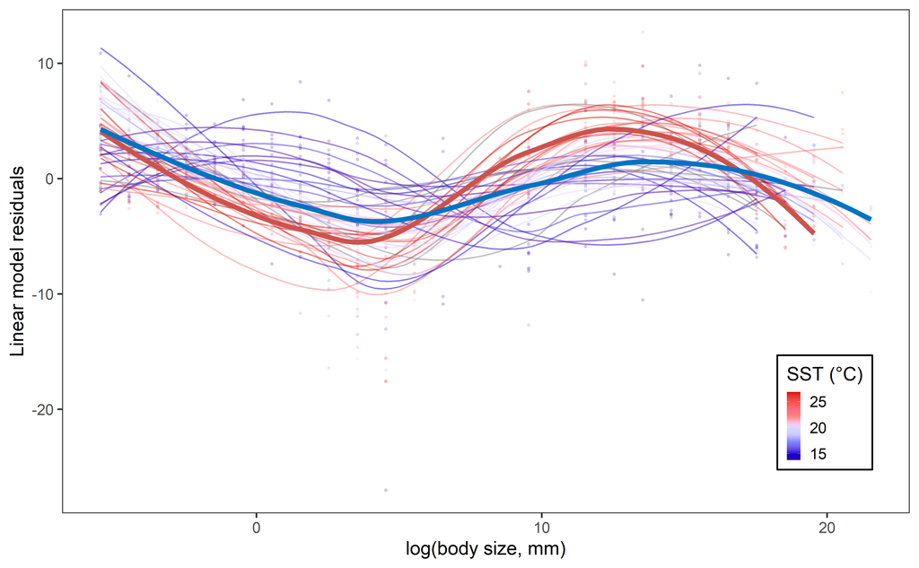

```r
site_lm <- lm(logsqrt2(norm_density) ~ logsqrt2(bin_mid) + site_code, data = main_df)

fig2_data <-
  main_df %>%
  mutate(lm_residuals = sqrt(2)^site_lm$residuals) %>%
  mutate(lat_zone = case_when(abs(lat) < 23.5 ~ "Tropical",
                              TRUE ~ "Temperate")) %>%
  mutate(lat_zone = as.factor(lat_zone),
         site_code = as.factor(site_code)) %>%
  left_join(enviro_df %>% select(site_code, sstmean), by = "site_code")

fig_2 <-
  fig2_data %>%
  ggplot() +
  aes(x = bin_mid %>% logsqrt2,
      y = lm_residuals %>% logsqrt2,
      col = sstmean) +
  geom_point(alpha = 0.2, aes(group = site_code)) +
  geom_line(stat= "smooth", method = "loess", se=F, size = 1, alpha = 0.5, aes(group = site_code)) +
  ggsci::scale_colour_gsea(breaks = c(15, 20, 25)) +
  theme_bw(24) +
  theme(legend.position = c(0.9, 0.2),
        legend.background = element_rect(fill = "transparent", colour = "black")) +
  labs(col = "SST (°C)")+
  xlab("log(body size, mm)") +
  ylab("Linear model residuals") +
  # scale_y_continuous(trans = log_trans(base = sqrt(2)),
  #                    breaks = c(10^c(-4:2)),
  #                    labels = trans_format("log10", math_format(10^.x))) +
  # scale_x_continuous(trans = log_trans(base = sqrt(2)),
  #                    breaks = c(10^c(-5:5)),
  #                    labels = trans_format("log10", math_format(10^.x))) +
  geom_line(stat= "smooth", method = "loess", se=F, size = 3, alpha = 1,
            data = fig2_data %>% filter(lat_zone == "Tropical"), col = mypal[4]) +
  geom_line(stat= "smooth", method = "loess",se=F, size = 3, alpha = 1,
            data = fig2_data %>% filter(lat_zone == "Temperate"), col = mypal[1]) +
  theme(panel.grid.major = element_blank(),
        panel.grid.minor = element_blank())

save_as_plot(plot = fig_2, filename = "fig_2", output_type = c("png", "eps", "pdf"))
knitr::include_graphics("output/figs/png/fig_2.png")
```

## Figure 3

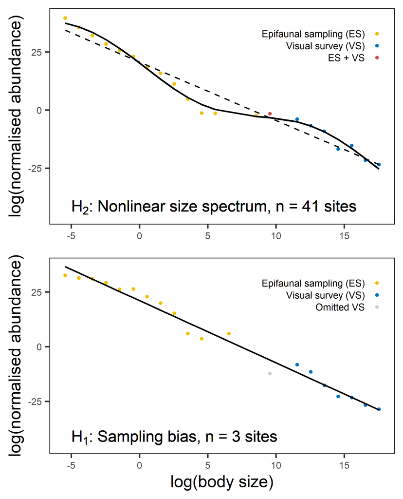

```r
# GBR27
# NIN-S1
site_plot_dat <- main_df %>% filter(site_code == "GBR27") %>% left_join(mod_fits) %>% left_join(lm_fits)
fig_3a <-
  site_plot_dat %>%
  mutate(type = factor(type, levels = c("meio", "macro", "both"))) %>%
  ggplot(aes(bin_mid %>% logsqrt2, norm_density%>% logsqrt2)) +
  geom_point(aes(col = type), size = 2) +
  # geom_point(data = site_plot_dat %>% filter(type == "meio"), col = meio_col, size = 2) +
  # geom_point(data = site_plot_dat %>% filter(type == "macro"), col = macr_col, size = 2) +
  # geom_point(data = site_plot_dat %>% filter(type == "both"), col = both_col, size = 2) +
  geom_line(aes(y = nls_fit %>% logsqrt2), size = 1.2) +
  geom_line(aes(y = lm_fit %>% logsqrt2), lty= 2, size = 1) +
  xlab("log(body size)") +
  ylab("log(normalised abundance)") +
  theme_bw(24) +
  theme(strip.background = element_blank(),
        strip.text.x = element_blank(),
        axis.text = element_text(size = 14), legend.position = "none") +
  geom_text(aes(x = -5, y = -45, label = "paste(H[2], ': Nonlinear size spectrum, n = 41 sites')"),
            size = 8, hjust = 0, vjust = 0, parse = T)+
  theme(panel.grid.major = element_blank(),
        panel.grid.minor = element_blank(),
        # axis.text.x = element_blank(),
        # axis.ticks.x = element_blank(),
        axis.title.x = element_blank()
  ) +
  theme(legend.position = c(0.99, 0.99),
        legend.justification=c(1, 1),
        legend.text = element_text(size = 14),
        legend.title = element_text(size = 18),
        legend.text.align = 1,
        legend.background = element_rect(fill = "transparent", colour = "transparent")) +
  scale_color_manual(name = element_blank(),
                     labels = c("Epifaunal sampling (ES)", "Visual survey (VS)", "ES + VS" ),
                     values = c(meio_col, macr_col, both_col)) +
  guides(col = guide_legend(title.position = "top",
                            # hjust = 0.5 centres the title horizontally
                            title.hjust = 0.8,
                            label.position = "left"))

site_plot_dat2 <- main_df %>% filter(site_code == "NIN-S1") %>% left_join(mod_fits) %>% left_join(lm_fits)
fig_3b <-
  site_plot_dat2 %>%
  mutate(type = case_when(type == "macro" & bin_mid < 54.6 ~ "ommitted",
                          TRUE ~ type)) %>%
  mutate(type = factor(type, levels = c("meio", "macro", "ommitted"))) %>%
  ggplot(aes(bin_mid %>% logsqrt2, norm_density%>% logsqrt2)) +
  geom_point(aes(col = type), size = 2) +
  # geom_point(data = site_plot_dat2 %>% filter(type == "meio"), col = meio_col, size = 2) +
  # geom_point(data = site_plot_dat2 %>% filter(type == "macro"), col = macr_col, size = 2) +
  # geom_point(data = site_plot_dat2 %>% filter(type == "both"), col = both_col, size = 2) +
  # geom_point(data = site_plot_dat2 %>% filter(), col = "grey80", size = 2) +
  # geom_line(aes(y = nls_fit %>% logsqrt2)) +
  geom_line(aes(y = lm_fit %>% logsqrt2), size = 1.2) +
  xlab("log(body size)") +
  ylab("log(normalised abundance)") +
  theme_bw(24) +
  theme(strip.background = element_blank(),
        strip.text.x = element_blank(),
        axis.text = element_text(size = 14), legend.position = "none") +
  geom_text(aes(x = -5, y = -45, label = "paste(H[1], ': Sampling bias, n = 3 sites')"),
            size = 8, hjust = 0, vjust = 0, parse = T) +
  theme(panel.grid.major = element_blank(),
        panel.grid.minor = element_blank()
  ) +
  theme(legend.position = c(0.99, 0.99),
        legend.justification=c(1, 1),
        legend.text = element_text(size = 14),
        legend.title = element_text(size = 18),
        legend.background = element_rect(fill = "transparent", colour = "transparent")) +
  scale_color_manual(name = element_blank(),
                     labels = c("Epifaunal sampling (ES)", "Visual survey (VS)", "Omitted VS" ),
                     values = c(meio_col, macr_col, "grey80")) +
  guides(col = guide_legend(title.position = "top",
                            # hjust = 0.5 centres the title horizontally
                            title.hjust = 0.8,
                            label.position = "left"))

site_plot_dat2 <- main_df %>% filter(site_code == "NIN-S1") %>% left_join(mod_fits) %>% left_join(lm_fits)
fig_3 <-
  plot_grid(fig_3a, fig_3b,
            # labels = c('A', 'B'),
            # label_size = 24,
            ncol = 1)

save_as_plot(plot = fig_3, filename = "fig_3", output_type = c("png", "eps", "pdf"), asp_ratio = 1.618/2)
knitr::include_graphics("output/figs/png/fig_3.png")
```

## Figure 4

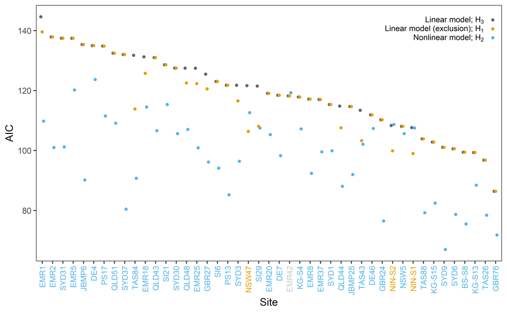

```r
fig_4_data <-
  lm_output %>%
  select(site_code, lm_AIC) %>%
  left_join(nls_output %>%
              select(site_code, nls_AIC)) %>%
  left_join(lm_output2 %>%
              select(site_code, lm2_AIC)) %>%
  mutate(hypothesis = case_when(lm2_AIC < lm_AIC & lm2_AIC < nls_AIC ~ "H1",
                                nls_AIC <= lm_AIC & nls_AIC <= lm2_AIC ~ "H2",
                                lm_AIC <= lm2_AIC & lm_AIC <= nls_AIC ~ "NA")) %>%
  mutate(lm_AIC_delta = lm_AIC-lm_AIC) %>%
  mutate(nls_AIC_delta = nls_AIC-lm_AIC) %>%
  mutate(lm2_AIC_delta = lm2_AIC-lm_AIC) %>%
  mutate(lm_AIC_delta = lm_AIC_delta %>% decplaces) %>%
  mutate(nls_AIC_delta = nls_AIC_delta %>% decplaces) %>%
  mutate(lm2_AIC_delta = lm2_AIC_delta %>% decplaces) %>%
  mutate(lm_AIC_forsorting = lm_AIC) %>%
  pivot_longer(cols = c(lm_AIC, nls_AIC, lm2_AIC),
               names_to = "model",
               values_to = "AIC")
x_title_cols <-
  fig_4_data %>%
  mutate(cols = case_when(hypothesis == "H1"~ "#E69F00",
                          hypothesis == "H2"~ "#56B4E9",
                          hypothesis == "H3"~ "grey40",
                          TRUE ~ "grey80")) %>%
  arrange(desc(lm_AIC_forsorting)) %>%
  select(site_code, cols) %>%
  distinct() %>%
  pull(cols)

fig_4 <-
  fig_4_data %>%
  ggplot(aes(forcats::fct_reorder(site_code, desc(lm_AIC_forsorting)), AIC, col = model)) +
  geom_point(position = position_dodge(width = 0.4), size = 3) +
  theme_bw(24) +
  xlab("Site") +
  theme(
    panel.grid.major = element_blank(),
        panel.grid.minor = element_blank(),
        # panel.border = element_blank(),
        axis.text.x=element_text(angle=90, vjust=0.5, hjust=1, size = 18,
                              colour = x_title_cols),
        legend.position = c(1, 1),
        legend.text = element_text(size = 18),
        legend.title = element_blank(),
        legend.justification = c(1,1),
        legend.background = element_rect(colour = "transparent", fill = "transparent")) +
  scale_color_manual(labels = c(expression(paste("Linear model; ",H[3])),
                                expression(paste("Linear model (exclusion); ",H[1])),
                                expression(paste("Nonlinear model; ",H[2]))),
                     values=c("grey40", "#E69F00", "#56B4E9")) +
  guides(col = guide_legend(title.position = "top",
                            # hjust = 0.5 centres the title horizontally
                            title.hjust = 0.8,
                            label.position = "left"))
save_as_plot(plot = fig_4, filename = "fig_4", output_type = c("png", "eps", "pdf"))
knitr::include_graphics("output/figs/png/fig_4.png")
```

## Information for text

```r
# How much variation in Abundance is explained by body size? (all sites combined)
lm(logsqrt2(norm_density) ~ logsqrt2(bin_mid), data = main_df) %>%
  get_adjr2() %>%
  `*`(100)
```

```
## [1] 95.88566
```

```r
# Macro only data
lm(logsqrt2(norm_density) ~ logsqrt2(bin_mid), data = read_csv("data/base/main_df_macroonly.csv") ) %>%
  get_adjr2() %>%
  `*`(100)
```

```
## [1] 84.33641
```

```r
# Meio only data
lm(logsqrt2(norm_density) ~ logsqrt2(bin_mid), data = read_csv("data/base/main_df_meioonly.csv") ) %>%
  get_adjr2() %>%
  `*`(100)
```

```
## [1] 90.11178
```

```r
macro_taxa <-
  read_csv("data/base/macro_taxa.csv") %>%
  group_by(species_name, class) %>%
  summarise(max_obs_length_cm = max(size_class, na.rm = T)) %>%
  arrange(desc(max_obs_length_cm))
meio_taxa <-
  data.table::fread("data/base/epi_taxa.csv") %>%
  filter(BR.TAXA != "unknown worm") %>%
  select(BR.TAXA) %>%
  distinct() %>%
  as_tibble() %>%
  rename("Broad Taxa" = BR.TAXA)

write_csv(macro_taxa, "data/processed/macro_taxa_list.csv")
write_csv(meio_taxa, "data/processed/meio_taxa_list.csv")


nls_coefs %>%
  mutate(ppsr = sqrt(2)^(D/2)) %>%
  summarise(confintmean = mean(ppsr),
              confint = confidence_interval(ppsr, 0.95)) %>%
  mutate(diff = confint - confintmean)
```

```
## # A tibble: 2 x 3
##   confintmean confint  diff
##         <dbl>   <dbl> <dbl>
## 1        28.1    17.8 -10.3
## 2        28.1    38.4  10.3
```

# Supplementary

## Figure S1

```r
ecor_labels <-
  main_df %>%
  group_by(ecoregion) %>%
  summarise(mean_lat = mean(lat),
            mean_lon = mean(lon),
            .groups = "drop") %>%
  mutate(label_ecor = case_when(ecoregion == "Central and Southern Great Barrier Reef" ~
                                  "Central and Southern \n Great Barrier Reef (GBR)",
                                ecoregion == "Lord Howe and Norfolk Islands" ~
                                  "Lord Howe & \n Norfolk Islands (LHN)",
                                ecoregion == "Torres Strait Northern Great Barrier Reef" ~
                                  "Torres Strait Northern \n Great Barrier Reef (TS)",
                                ecoregion == "Bassian" ~
                                  "Bassian (BA)",
                                ecoregion == "Cape Howe" ~
                                  "Cape Howe (CH)",
                                ecoregion == "Manning-Hawkesbury" ~
                                  "Manning-Hawkesbury (MH)",
                                ecoregion == "Tweed-Moreton" ~
                                  "Solitary Islands (SI)")) %>%
  mutate(label_ecor_abbr = case_when(ecoregion == "Central and Southern Great Barrier Reef" ~ "GBR",
                                     ecoregion == "Lord Howe and Norfolk Islands" ~ "LHN",
                                     ecoregion == "Torres Strait Northern Great Barrier Reef" ~ "TS",
                                     ecoregion == "Bassian" ~ "BA",
                                     ecoregion == "Cape Howe" ~ "CH",
                                     ecoregion == "Manning-Hawkesbury" ~ "MH",
                                     ecoregion == "Tweed-Moreton" ~ "TH")) %>%
  mutate(label_pos_lon = case_when(ecoregion == "Cape Howe" ~ mean_lon + 2,
                                   ecoregion == "Lord Howe and Norfolk Islands" ~ mean_lon -3.2,
                                   ecoregion == "Tweed-Moreton" ~ mean_lon,
                                   TRUE ~ mean_lon + 1)) %>%
  mutate(label_pos_lat = case_when(ecoregion == "Lord Howe and Norfolk Islands" ~ mean_lat + 2.5,
                                   ecoregion == "Tweed-Moreton" ~ mean_lat -1,
                                   TRUE ~ mean_lat))

site_labels <-
  main_df %>%
  mutate(site_label_abbr = gsub("[^a-zA-Z]", "", site_code)) %>%
  mutate(site_label = case_when(site_label_abbr == "SYD" ~ "Sydney (SYD)",
                                site_label_abbr == "JBMP" ~ "Jervis Bay Marine Park (JBMP)",
                                site_label_abbr == "SI" ~ "Solitary islands (SI)",
                                site_label_abbr == "PS" ~ "Port Stevens (PS)",
                                site_label_abbr == "NSW" ~ "New South Wales (NSW)",
                                site_label_abbr == "QLD" ~ "Queensland (QLD)",
                                site_label_abbr == "DE" ~ "Derwent Estuary (DE)",
                                site_label_abbr == "TAS" ~ "Tasmania (TAS)",
                                site_label_abbr == "EMR" ~ "Elizabeth & Middleton Reef (EMR)",
                                site_label_abbr == "KGS" ~ "Kent Group (KG)",
                                site_label_abbr == "BSS" ~ "Bass Strait (BS)",
                                site_label_abbr == "NINS" ~ "Ninepin (NIN)",
                                site_label_abbr == "GBR" ~ "Great Barrier Reef (GBR)",
  )) %>%
  group_by(site_label, site_label_abbr, ecoregion) %>%
  summarise(mean_lat = mean(lat),
            mean_lon = mean(lon) ) %>%
  mutate(label_lon = case_when(site_label_abbr == "EMR" ~ mean_lon - 5,
                               site_label_abbr == "TAS" ~ mean_lon + 1.5,
                               TRUE ~ mean_lon  + 1)) %>%
  mutate(label_lat = case_when(site_label_abbr == "EMR" ~ mean_lat + 1.5,
                               site_label_abbr == "SI" ~ mean_lat -0.75,
                               site_label_abbr == "BSS" ~ mean_lat + 0.45,
                               site_label_abbr == "KGS" ~ mean_lat - 0.35,
                               site_label_abbr == "TAS" ~ mean_lat + 0.75,
                               site_label_abbr == "NINS" ~ mean_lat - 0.75,
                               TRUE ~ mean_lat))
```

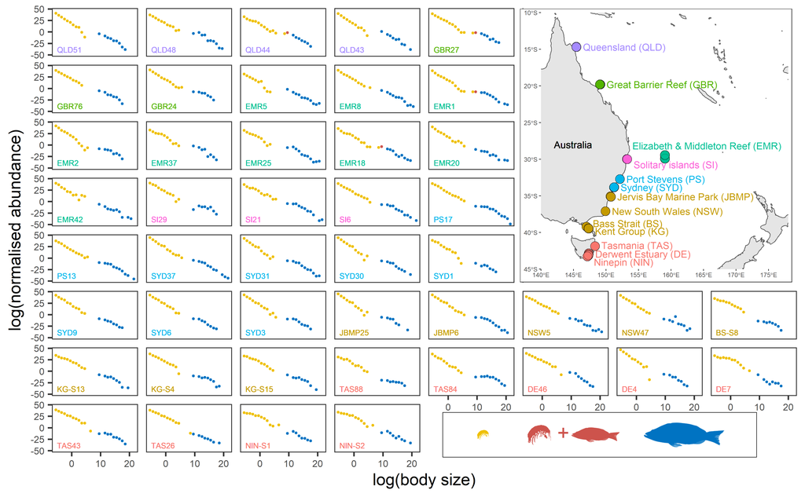

```r
fig_s1_map_empty <-
  ggplot(data = ne_countries(scale = "medium", returnclass = "sf")) +
  geom_sf() +
  coord_sf(xlim = c(140, 178), ylim = c(-45, -10), expand = FALSE) +
  geom_text(aes(x = 142, y = -28, label = "Australia"), hjust = 0, vjust = 0.5, size = 5) +
  theme(legend.position = "none") +
  theme(plot.background = element_rect(fill = "white", colour = "black")) +
  theme(axis.title = element_blank()) +
  theme(panel.background = element_rect(fill = "white")) +
  theme(panel.grid.major = element_line(colour = "grey90"))


fig_s1_map <-
  fig_s1_map_empty +
  geom_point(data = main_df, aes(x = lon, y = lat, fill = ecoregion),
             size = 6, alpha = 0.5, pch = 21, col = "black") +
  geom_text(aes(x = label_lon, y = label_lat, label = site_label, colour = ecoregion),
            data = site_labels, check_overlap = F, hjust = 0, vjust = 0.5, size = 5) +
  theme(panel.grid.major = element_blank(),
        panel.grid.minor = element_blank())

sites_desc_lat <-
  main_df %>%
  arrange(desc(lat)) %>%
  pull(site_code) %>%
  unique()

site_ord <- tibble(site_code = sites_desc_lat, id = 1:length(sites_desc_lat))

# creating empty sites in facet so that map can cover them
empty_sites <- tibble()
for(i in 1:5){

  empty_sites_lat <-
    main_df %>%
    left_join(site_ord, by = "site_code") %>%
    arrange(id) %>%
    filter(id == 5+(5*(i-1))) %>%
    pull(lat) %>%
    unique()

  empty_sites <-
    bind_rows(empty_sites,
              tibble(site_code = c(paste("empty", i, "_1"), paste("test", i, "_2"), paste("empty", i, "_3")),
                     lat = empty_sites_lat - c(0.00001, 0.00002,0.00003)))
}

fig_s1_data <-
  main_df %>%
  bind_rows(empty_sites) %>%
  mutate(site_ord = factor(site_code, levels = sites_desc_lat)) %>%
  left_join(ecor_labels)
# have to do this again for the new dataframe (with empty sites)
sites_desc_lat_new <-
  fig_s1_data %>%
  arrange(desc(lat)) %>%
  pull(site_code) %>%
  unique()

fig_s1_plots <-
  fig_s1_data %>%
  mutate(site_ord = factor(site_code, levels = sites_desc_lat_new)) %>%
  ggplot(aes(bin_mid %>% logsqrt2, norm_density%>% logsqrt2)) +
  geom_point(data = fig_s1_data %>% filter(type == "meio"), col = meio_col) +
  geom_point(data = fig_s1_data %>% filter(type == "macro"), col = macr_col) +
  geom_point(data = fig_s1_data %>% filter(type == "both"), col = both_col) +
  facet_wrap(~site_ord) +
  xlab("log(body size)") +
  ylab("log(normalised abundance)") +
  # scale_x_continuous(trans = log_trans(base = sqrt(2)),
  #                    breaks = c(10^c(-5, 0,  5)),
  #                    labels = trans_format("log10", math_format(10^.x))) +
  # scale_y_continuous(trans = log_trans(base = sqrt(2)),
  #                    breaks = c(10^c(-5, 0, 5, )),
  #                    labels = trans_format("log10", math_format(10^.x))) +
  theme_bw(24) +
  theme(strip.background = element_blank(),
        strip.text.x = element_blank(),
        axis.text = element_text(size = 14), legend.position = "none") +
  geom_text(aes(x = -5, y = -45, label = site_code, col = ecoregion),
            size = 4, hjust = 0, vjust = 0)+
  theme(panel.grid.major = element_blank(),
        panel.grid.minor = element_blank())


rect <- grid::rectGrob(gp = grid::gpar(fill = "transparent"), width = .39, height = .09, x = .55, y = 0.125, hjust = 0, vjust = 0.5)

fig_s1_legend_graphics <-
  list(
    draw_image(fish_image,
               x = 0.35,
               y = -0.375, scale = .1) ,
    draw_image(copepod_image,
               x = 0.1,
               y = -0.375,
               scale = .02) ,
    draw_image(fish_image %>% magick::image_colorize(opacity = 100, color = both_col),
               x = 0.24,
               y = -0.375, scale = .06) ,
    draw_image(copepod_image %>% magick::image_colorize(opacity = 100, color = both_col),
               x = 0.17,
               y = -0.375,
               scale = .04) ,
    draw_label("+", colour = both_col, x = 0.7, y = 0.13, size = 30) ,
    draw_grob(rect)
  )


fig_s1 <-
  ggdraw() +
  draw_plot(fig_s1_plots) +
  geom_rect(aes(xmin = 0.65, xmax = 0.99, ymin = 0.42, ymax = 0.99), fill = "white") +
  draw_plot(fig_s1_map, x = 0.615, y = 0.432, width = 0.4, height = 0.55) +
  fig_s1_legend_graphics

save_as_plot(plot = fig_s1, filename = "fig_s1", output_type = c("png", "eps", "pdf"))
knitr::include_graphics("output/figs/png/fig_s1.png")
```

**Figure 1.1** Size spectra for rocky and coral reef ecological communities covering 11 orders of magnitude in consumer size, from 3 µg to 150 kg, at 45 sites along the 28° latitude along the Eastern coast of Australia (sites ordered by latitude). Yellow data points represent data from epifaunal sampling, blue data points represent individuals from visual surveys and red data points represent size bins that contain animals from both sampling methods.

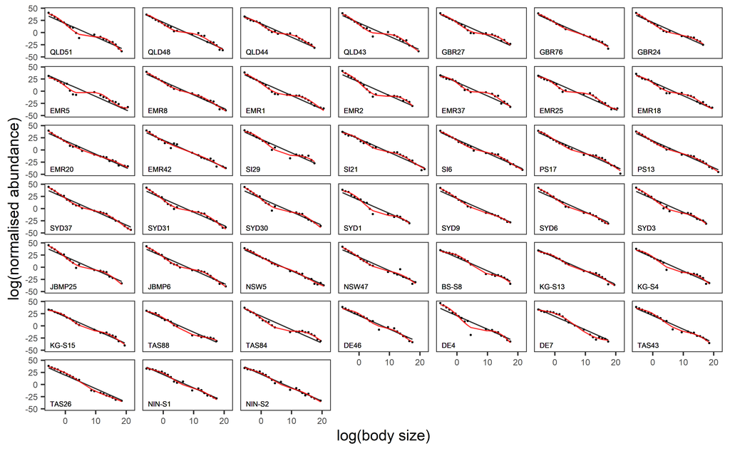

```r
fig_s2 <-
  mod_fits %>%
  left_join(main_df %>%
              mutate(lm_fit = sqrt(2)^predict(site_lm))) %>%
  mutate(site_ord = factor(site_code, levels = sites_desc_lat)) %>%
  ggplot() +
  aes(bin_mid %>% logsqrt2, norm_density %>% logsqrt2) +
  geom_point(size = 1.2) +
  facet_wrap(~site_ord) +
  geom_line(aes(y = lm_fit %>% logsqrt2), col = "black", size = 1, alpha = 0.8) +
  geom_line(aes(y = nls_fit %>% logsqrt2), col = "red", size = 1, alpha = 0.8) +
  theme_bw(24) +
  theme(strip.background = element_blank(),
        strip.text.x = element_blank(),
        axis.text = element_text(size = 14), legend.position = "none") +
  xlab("log(body size)") +
  ylab("log(normalised abundance)") +
  # scale_y_continuous(trans = log_trans(base = sqrt(2)),
  #                    breaks = c(10^c(-10, 0, 10)),
  #                    labels = trans_format("log10", math_format(10^.x))) +
  # scale_x_continuous(trans = log_trans(base = sqrt(2)),
  #                    breaks = c(10^c(-5, 0, 5)),
  # labels = trans_format("log10", math_format(10^.x))) +
  geom_text(aes(x = -5, y = -45, label = site_code), size = 4, hjust = 0, vjust = 0)+
  theme(panel.grid.major = element_blank(),
        panel.grid.minor = element_blank())
save_as_plot(plot = fig_s2, filename = "fig_s2", output_type = c("png", "eps", "pdf"))
knitr::include_graphics("output/figs/png/fig_s2.png")
```

**Figure S1.1** Continuous abundance size spectrum spanning 11 orders of magnitude in body size, with a fitted linear model (black, Equation S1.1) and non-linear model (red, Equation 1 in main text).

## Figure S3

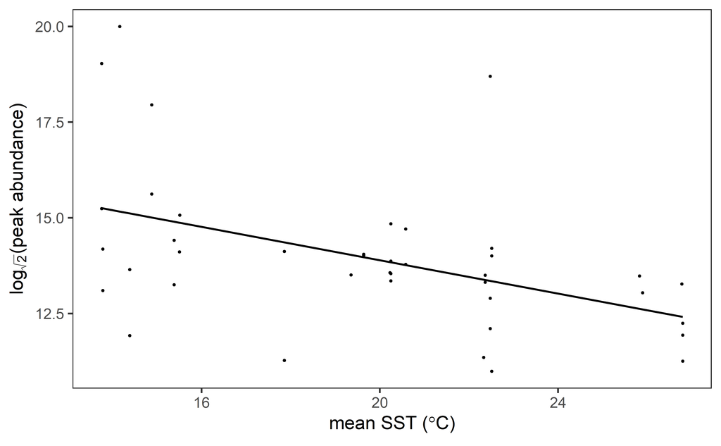

```r
fig_s3_data <-
  nls_coefs %>%
  left_join(enviro_df) %>%
  select(peak, sstmean, wave_exposure) %>%
  na.omit()
lm_peak_basic <- lm(peak ~ sstmean, data = fig_s3_data)

fig_s3_pal <- wesanderson::wes_palette(n = 5, name = "Darjeeling1")[c(1:3, 5)]

fig_s3 <-
  nls_coefs %>%
  left_join(enviro_df) %>%
  mutate(wave_exposure = as.factor(wave_exposure)) %>%
  drop_na(wave_exposure, sstmean) %>%
  mutate(fit_maxima = predict(lm_peak_basic)) %>%
  ggplot(aes(sstmean, peak)) +
  geom_point(size = 2) +
  theme_bw(30) +
  xlab(expression("mean SST ("*degree*"C)")) +
  ylab(expression(log[sqrt(2)]*"(peak abundance)")) +
  geom_line(aes(y = fit_maxima), size = 1.5) +
  scale_color_manual(values = fig_s3_pal) +
  labs(col = "Wave exposure") +
  theme(panel.grid.major = element_blank(),
        panel.grid.minor = element_blank())
save_as_plot(plot = fig_s3, filename = "fig_s3", output_type = c("png", "eps", "pdf"))
knitr::include_graphics("output/figs/png/fig_s3.png")
```

```r
sstrange <- enviro_df$sstmean %>% range(na.rm = T)
sqrt(2)^predict(lm_peak_basic, newdata = list(sstmean = sstrange))/10
```

```
##         1         2
## 19.764922  7.379767
```

## Table S4.2

```r
enviro_mod_data <-
  nls_coefs %>%
  left_join(enviro_df, by = "site_code") %>% na.omit()


best_A <- olsrr::ols_step_best_subset(lm(A ~ ., data = enviro_mod_data %>% select(-c(site_code, D, P, beta_0, lambda, peak))) )
best_D <- olsrr::ols_step_best_subset(lm(D ~ ., data = enviro_mod_data %>% select(-c(site_code, A, P, beta_0, lambda, peak))) )
best_lambda <- olsrr::ols_step_best_subset(lm(lambda ~ ., data = enviro_mod_data %>% select(-c(site_code, D, P, beta_0, A, peak))) )
best_peak <- olsrr::ols_step_best_subset(lm(peak ~ ., data = enviro_mod_data %>% select(-c(site_code, D, P, beta_0, lambda, A))) )

best_A$predictors[which.min(best_A$aic)]
```

```
## [1] "chlomean nitrate phos wave_exposure reef_slope"
```

```r
best_D$predictors[which.min(best_D$aic)]
```

```
## [1] "wave_exposure relief reef_slope"
```

```r
best_lambda$predictors[which.min(best_lambda$aic)]
```

```
## [1] "sstmean chlomean nitrate wave_exposure relief currents"
```

```r
best_peak$predictors[which.min(best_peak$aic)]
```

```
## [1] "sstmean wave_exposure relief reef_slope"
```

```r
lm_A      <- lm(A ~ chlomean + nitrate + phos + wave_exposure + reef_slope, data = enviro_mod_data)
lm_D      <- lm(D ~ wave_exposure + relief + reef_slope, data = enviro_mod_data)
lm_lambda <- lm(lambda ~ sstmean + chlomean + nitrate + wave_exposure + relief + currents, data = enviro_mod_data)
lm_peak   <- lm(peak ~  sstmean + wave_exposure + relief + reef_slope, data = enviro_mod_data)

get_percent_r2 <- function(lm_mod) ((get_adjr2(lm_mod)*100) %>% round()) %>% paste0(., "%")

tribble(~parameter, ~predictors, ~adj_r_squared,
        "A", best_A$predictors[which.max(best_A$adjr)], get_percent_r2(lm_A),
        "D", best_D$predictors[which.max(best_A$adjr)], get_percent_r2(lm_D),
        "lambda", best_lambda$predictors[which.max(best_A$adjr)], get_percent_r2(lm_lambda),
        "peak", best_peak$predictors[which.max(best_A$adjr)], get_percent_r2(lm_peak))
```

```
## # A tibble: 4 x 3
##   parameter predictors                                       adj_r_squared
##   <chr>     <chr>                                            <chr>
## 1 A         chlomean nitrate phos wave_exposure reef_slope   31%
## 2 D         chlomean phos wave_exposure relief reef_slope    19%
## 3 lambda    sstmean chlomean nitrate wave_exposure currents  60%
## 4 peak      sstmean chlomean wave_exposure relief reef_slope 35%
```